# 기술통계

- 자료를 그래프나 숫자등으로 요약하는 통계적 행위 및 관련 방법
- 데이터를 요약하고 시각화해서 잘 설명하는 것이 중점을 두며 데이터에 대해서 쉽게 설명하기 위해서 시각화를 많이 활용한다.
- 기술 통계에서 기본적으로 사용하는 것
  - 도수분포표
  - 히스토그램
  - 박스플롯(상자그림)
- 이를 기반으로 사실을 객관적으로 확인하는 것을 중점으로 한다.

## 기술통계 절차

1. 데이터의 전체 크기 확인
   - 행과 열의 수를 확인한다.
2. 데이터의 형태 확인
   - 10만건의 데이터 전체를 출력하는 것은 매우 부담이 큰 처리이므로 상위 n건, 하위 n건의 일부만을 확인한다.
3. 집단의 특성을 잘 나타내는 요약 통계량을 확인한다.
   - 평균, 중앙값, 표준편차, 범위(최대값~최소값), 사분위수 등을 확인한다.
4. 전체 데이터의 데이터 분포를 확인한다.
   - 구간별 자료의 개수를 나타내는 표(=도수분포표)를 산정한다.
   - 도수 분포표를 그래프로 표현한 히스토그램을 확인한다.

## 자료의 분류

### 1) 범주형 자료

> 데이터의 빈도를 측정한 후 도수분포와 히스토그램을 통해 데이터 분포를 확인
1. 명목형 자료
   - 숫자로 바꾸어도 크고 작음을 나타내는 것이 아니라 단순히 범주를 표시함
   - ex) 성별, 주민번호, 혈액형, 연락처
2. 순서형 자료
   - 범주의 순서가 상대적으로 비교 가능
   - ex) 비만도(저체중,정상,과체중,비만,고도비만), 학점
   - 대부분 수치형 자료를 그룹화 하여 순서형 자료로 변환함

### 2) 수치형 자료

> 요약정보 표와 상자그림을 통해 데이터 분포를 확인 (도수분포와 히스토그램도 사용가능함)
1. 이산자료
   - 셀 수 있는 형태의 자료
   - ex) 학생 수
2. 연속자료
   - 연속적인 속성을 갖는 자료
   - ex) 신장, 체중, 점수
   - 연속성 자료는 이산화를 통해 자연수 형태로 표시되는 경우가 많음

## 필요한 패키지 및 샘플 데이터 준비

```python
from pandas import DataFrame 	# 모듈 참조
from pandas import read_csv     # 모듈참조
from matplotlib import pyplot	# 모듈 참조
from sample import height	    # 데이터 참조
```

```python
# 학생키 데이터 -> 도수분포와 히스토그램 확인을 위한 샘플 데이터
학생키 = DataFrame(height)
학생키
```

|  | 키 |
| --- | --- |
| 0 | 170 |
| 1 | 178 |
| 2 | 171 |
| 3 | 168 |
| 4 | 173 |
| 5 | 178 |
| 6 | 171 |
| 7 | 174 |
| 8 | 170 |
| 9 | 170 |
| 10 | 175 |
| 11 | 170 |
| 12 | 169 |
| 13 | 166 |
| 14 | 162 |
| 15 | 170 |
| 16 | 171 |
| 17 | 175 |
| 18 | 175 |
| 19 | 171 |
| 20 | 170 |
| 21 | 172 |
| 22 | 179 |
| 23 | 164 |
| 24 | 170 |
| 25 | 181 |
| 26 | 178 |
| 27 | 180 |
| 28 | 177 |
| 29 | 166 |
| 30 | 169 |
| 31 | 168 |
| 32 | 165 |
| 33 | 163 |
| 34 | 175 |
| 35 | 166 |
| 36 | 178 |
| 37 | 165 |
| 38 | 168 |
| 39 | 167 |
| 40 | 177 |
| 41 | 168 |
| 42 | 177 |
| 43 | 174 |
| 44 | 174 |
| 45 | 176 |
| 46 | 169 |
| 47 | 173 |
| 48 | 167 |
| 49 | 170 |
| 50 | 173 |
| 51 | 170 |
| 52 | 162 |
| 53 | 182 |
| 54 | 171 |

```python
# 성적표 데이터 -> 기술통계 수치값, 상자그림 확인을 위한 샘플 데이터
성적표csv = read_csv("http://itpaper.co.kr/demo/python/grade.csv", encoding="euc-kr")
성적표csv
```

|  | 이름 | 국어 | 영어 | 수학 | 과학 |
| --- | --- | --- | --- | --- | --- |
| 0 | 학생1 | 98.0 | NaN | 88.0 | 64.0 |
| 1 | 학생2 | 88.0 | 90.0 | 62.0 | 72.0 |
| 2 | 학생3 | 92.0 | 70.0 | NaN | NaN |
| 3 | 학생4 | 63.0 | 60.0 | 31.0 | 70.0 |
| 4 | 학생5 | 100.0 | 50.0 | NaN | 88.0 |
| 5 | 학생6 | 56.0 | 49.0 | 90.0 | 44.0 |
| 6 | 학생7 | 34.0 | 28.0 | 16.0 | 0.0 |
| 7 | 학생8 | 37.0 | 13.0 | 9.0 | 41.0 |
| 8 | 학생9 | 14.0 | 17.0 | 21.0 | 77.0 |
| 9 | 학생10 | 37.0 | 20.0 | 3.0 | 77.0 |
| 10 | 학생11 | 19.0 | 97.0 | 28.0 | 77.0 |
| 11 | 학생12 | 57.0 | 85.0 | 33.0 | 84.0 |
| 12 | 학생13 | 10.0 | 21.0 | 67.0 | 54.0 |
| 13 | 학생14 | 79.0 | 74.0 | 14.0 | 59.0 |
| 14 | 학생15 | 96.0 | 67.0 | 66.0 | 48.0 |
| 15 | 학생16 | 46.0 | 25.0 | 54.0 | 56.0 |
| 16 | 학생17 | 66.0 | 32.0 | 77.0 | 24.0 |
| 17 | 학생18 | 46.0 | 25.0 | 2.0 | 12.0 |
| 18 | 학생19 | 26.0 | 10.0 | 49.0 | 74.0 |
| 19 | 학생20 | 97.0 | 68.0 | 65.0 | 33.0 |
| 20 | 학생21 | 86.0 | 70.0 | 99.0 | 45.0 |
| 21 | 학생22 | 31.0 | 62.0 | 37.0 | 82.0 |
| 22 | 학생23 | 43.0 | 88.0 | 11.0 | 56.0 |
| 23 | 학생24 | 6.0 | 98.0 | 96.0 | 74.0 |
| 24 | 학생25 | 41.0 | 75.0 | 8.0 | 22.0 |
| 25 | 학생26 | 29.0 | 45.0 | 94.0 | 70.0 |
| 26 | 학생27 | 83.0 | 84.0 | 32.0 | 91.0 |
| 27 | 학생28 | 91.0 | 1.0 | 53.0 | 32.0 |
| 28 | 학생29 | 89.0 | 59.0 | 10.0 | 29.0 |
| 29 | 학생30 | 84.0 | 58.0 | 70.0 | 25.0 |
| ... | ... | ... | ... | ... | ... |
| 9970 | 학생9971 | 70.0 | 41.0 | 86.0 | 93.0 |
| 9971 | 학생9972 | 20.0 | 88.0 | 73.0 | 46.0 |
| 9972 | 학생9973 | 63.0 | 60.0 | 55.0 | 70.0 |
| 9973 | 학생9974 | 21.0 | 50.0 | 55.0 | 88.0 |
| 9974 | 학생9975 | 98.0 | 90.0 | 88.0 | 64.0 |
| 9975 | 학생9976 | 88.0 | 90.0 | 62.0 | 72.0 |
| 9976 | 학생9977 | 92.0 | 70.0 | 75.0 | 85.0 |
| 9977 | 학생9978 | 86.0 | 90.0 | 98.0 | 92.0 |
| 9978 | 학생9979 | 90.0 | 92.0 | 94.0 | 98.0 |
| 9979 | 학생9980 | 64.0 | 54.0 | 73.0 | 83.0 |
| 9980 | 학생9981 | 89.0 | 36.0 | 63.0 | 14.0 |
| 9981 | 학생9982 | 83.0 | 26.0 | 81.0 | 98.0 |
| 9982 | 학생9983 | 18.0 | 51.0 | 17.0 | 6.0 |
| 9983 | 학생9984 | 85.0 | 37.0 | 23.0 | 49.0 |
| 9984 | 학생9985 | 90.0 | 93.0 | 65.0 | 30.0 |
| 9985 | 학생9986 | 71.0 | 83.0 | 15.0 | 11.0 |
| 9986 | 학생9987 | 94.0 | 6.0 | 28.0 | 69.0 |
| 9987 | 학생9988 | 90.0 | 92.0 | 94.0 | 98.0 |
| 9988 | 학생9989 | 32.0 | 59.0 | 16.0 | 31.0 |
| 9989 | 학생9990 | 59.0 | 64.0 | 40.0 | 72.0 |
| 9990 | 학생9991 | 85.0 | 73.0 | 51.0 | 6.0 |
| 9991 | 학생9992 | 20.0 | 36.0 | 26.0 | 73.0 |
| 9992 | 학생9993 | 46.0 | 56.0 | 39.0 | 24.0 |
| 9993 | 학생9994 | 70.0 | 41.0 | 86.0 | 93.0 |
| 9994 | 학생9995 | 20.0 | 88.0 | 73.0 | 46.0 |
| 9995 | 학생9996 | 63.0 | 60.0 | 55.0 | 70.0 |
| 9996 | 학생9997 | 21.0 | 50.0 | 55.0 | 88.0 |
| 9997 | 학생9998 | 98.0 | 90.0 | 88.0 | 64.0 |
| 9998 | 학생9999 | 88.0 | 90.0 | 62.0 | 72.0 |
| 9999 | 학생10000 | 92.0 | 70.0 | 75.0 | 85.0 |

10000 rows × 5 columns

### 성적표 데이터 전처리

```python
학생이름 = {}
for i, v in enumerate(list(성적표csv['이름'])):
    학생이름[i] = v

성적표df = 성적표csv.rename(index=학생이름).drop('이름', axis=1)
성적표df
```

|  | 국어 | 영어 | 수학 | 과학 |
| --- | --- | --- | --- | --- |
| 학생1 | 98.0 | NaN | 88.0 | 64.0 |
| 학생2 | 88.0 | 90.0 | 62.0 | 72.0 |
| 학생3 | 92.0 | 70.0 | NaN | NaN |
| 학생4 | 63.0 | 60.0 | 31.0 | 70.0 |
| 학생5 | 100.0 | 50.0 | NaN | 88.0 |
| 학생6 | 56.0 | 49.0 | 90.0 | 44.0 |
| 학생7 | 34.0 | 28.0 | 16.0 | 0.0 |
| 학생8 | 37.0 | 13.0 | 9.0 | 41.0 |
| 학생9 | 14.0 | 17.0 | 21.0 | 77.0 |
| 학생10 | 37.0 | 20.0 | 3.0 | 77.0 |
| 학생11 | 19.0 | 97.0 | 28.0 | 77.0 |
| 학생12 | 57.0 | 85.0 | 33.0 | 84.0 |
| 학생13 | 10.0 | 21.0 | 67.0 | 54.0 |
| 학생14 | 79.0 | 74.0 | 14.0 | 59.0 |
| 학생15 | 96.0 | 67.0 | 66.0 | 48.0 |
| 학생16 | 46.0 | 25.0 | 54.0 | 56.0 |
| 학생17 | 66.0 | 32.0 | 77.0 | 24.0 |
| 학생18 | 46.0 | 25.0 | 2.0 | 12.0 |
| 학생19 | 26.0 | 10.0 | 49.0 | 74.0 |
| 학생20 | 97.0 | 68.0 | 65.0 | 33.0 |
| 학생21 | 86.0 | 70.0 | 99.0 | 45.0 |
| 학생22 | 31.0 | 62.0 | 37.0 | 82.0 |
| 학생23 | 43.0 | 88.0 | 11.0 | 56.0 |
| 학생24 | 6.0 | 98.0 | 96.0 | 74.0 |
| 학생25 | 41.0 | 75.0 | 8.0 | 22.0 |
| 학생26 | 29.0 | 45.0 | 94.0 | 70.0 |
| 학생27 | 83.0 | 84.0 | 32.0 | 91.0 |
| 학생28 | 91.0 | 1.0 | 53.0 | 32.0 |
| 학생29 | 89.0 | 59.0 | 10.0 | 29.0 |
| 학생30 | 84.0 | 58.0 | 70.0 | 25.0 |
| ... | ... | ... | ... | ... |
| 학생9971 | 70.0 | 41.0 | 86.0 | 93.0 |
| 학생9972 | 20.0 | 88.0 | 73.0 | 46.0 |
| 학생9973 | 63.0 | 60.0 | 55.0 | 70.0 |
| 학생9974 | 21.0 | 50.0 | 55.0 | 88.0 |
| 학생9975 | 98.0 | 90.0 | 88.0 | 64.0 |
| 학생9976 | 88.0 | 90.0 | 62.0 | 72.0 |
| 학생9977 | 92.0 | 70.0 | 75.0 | 85.0 |
| 학생9978 | 86.0 | 90.0 | 98.0 | 92.0 |
| 학생9979 | 90.0 | 92.0 | 94.0 | 98.0 |
| 학생9980 | 64.0 | 54.0 | 73.0 | 83.0 |
| 학생9981 | 89.0 | 36.0 | 63.0 | 14.0 |
| 학생9982 | 83.0 | 26.0 | 81.0 | 98.0 |
| 학생9983 | 18.0 | 51.0 | 17.0 | 6.0 |
| 학생9984 | 85.0 | 37.0 | 23.0 | 49.0 |
| 학생9985 | 90.0 | 93.0 | 65.0 | 30.0 |
| 학생9986 | 71.0 | 83.0 | 15.0 | 11.0 |
| 학생9987 | 94.0 | 6.0 | 28.0 | 69.0 |
| 학생9988 | 90.0 | 92.0 | 94.0 | 98.0 |
| 학생9989 | 32.0 | 59.0 | 16.0 | 31.0 |
| 학생9990 | 59.0 | 64.0 | 40.0 | 72.0 |
| 학생9991 | 85.0 | 73.0 | 51.0 | 6.0 |
| 학생9992 | 20.0 | 36.0 | 26.0 | 73.0 |
| 학생9993 | 46.0 | 56.0 | 39.0 | 24.0 |
| 학생9994 | 70.0 | 41.0 | 86.0 | 93.0 |
| 학생9995 | 20.0 | 88.0 | 73.0 | 46.0 |
| 학생9996 | 63.0 | 60.0 | 55.0 | 70.0 |
| 학생9997 | 21.0 | 50.0 | 55.0 | 88.0 |
| 학생9998 | 98.0 | 90.0 | 88.0 | 64.0 |
| 학생9999 | 88.0 | 90.0 | 62.0 | 72.0 |
| 학생10000 | 92.0 | 70.0 | 75.0 | 85.0 |

10000 rows × 4 columns

## #01. 데이터의 전체 크기 확인

```python
# 데이터프레임의 전체 크기를 튜플로 조회
행,열 = 성적표df.shape
print("행의 크기 =", 행)
print("열의 크기 =", 열)
```

```
행의 크기 = 10000
열의 크기 = 4
```

## #02. 데이터의 일부만 확인하기

### 앞 부분의 5건만 확인

```python
성적표df.head()
```

|  | 국어 | 영어 | 수학 | 과학 |
| --- | --- | --- | --- | --- |
| 학생1 | 98.0 | NaN | 88.0 | 64.0 |
| 학생2 | 88.0 | 90.0 | 62.0 | 72.0 |
| 학생3 | 92.0 | 70.0 | NaN | NaN |
| 학생4 | 63.0 | 60.0 | 31.0 | 70.0 |
| 학생5 | 100.0 | 50.0 | NaN | 88.0 |

### 뒷 부분의 5건만 확인

```python
성적표df.tail()
```

|  | 국어 | 영어 | 수학 | 과학 |
| --- | --- | --- | --- | --- |
| 학생9996 | 63.0 | 60.0 | 55.0 | 70.0 |
| 학생9997 | 21.0 | 50.0 | 55.0 | 88.0 |
| 학생9998 | 98.0 | 90.0 | 88.0 | 64.0 |
| 학생9999 | 88.0 | 90.0 | 62.0 | 72.0 |
| 학생10000 | 92.0 | 70.0 | 75.0 | 85.0 |

## #03. 기술통계표 얻기

### 전체 컬럼에 대한 일괄 확인

```python
des = 성적표df.describe()
des
```

|  | 국어 | 영어 | 수학 | 과학 |
| --- | --- | --- | --- | --- |
| count | 9932.000000 | 9770.000000 | 9705.000000 | 9832.000000 |
| mean | 60.266512 | 57.069908 | 56.160330 | 60.420972 |
| std | 27.876303 | 23.391528 | 25.402649 | 28.826763 |
| min | 3.000000 | 1.000000 | 0.000000 | 0.000000 |
| 25% | 40.000000 | 41.000000 | 31.000000 | 35.000000 |
| 50% | 63.000000 | 56.000000 | 62.000000 | 70.000000 |
| 75% | 88.000000 | 72.000000 | 75.000000 | 85.000000 |
| max | 100.000000 | 98.000000 | 99.000000 | 99.000000 |

### 특정 컬럼에 대한 확인

```python
성적표df['국어'].describe()
```

```
count    9932.000000
mean       60.266512
std        27.876303
min         3.000000
25%        40.000000
50%        63.000000
75%        88.000000
max       100.000000
Name: 국어, dtype: float64
```

### 기술통계값들을 개별적으로 얻기

```python
성적표df.count()
```

```
국어    9932
영어    9770
수학    9705
과학    9832
dtype: int64
```

```python
성적표df.mean()
```

```
국어    60.266512
영어    57.069908
수학    56.160330
과학    60.420972
dtype: float64
```

```python
성적표df.max()
```

```
국어    100.0
영어     98.0
수학     99.0
과학     99.0
dtype: float64
```

```python
성적표df.min()
```

```
국어    3.0
영어    1.0
수학    0.0
과학    0.0
dtype: float64
```

```python
성적표df.std()
```

```
국어    27.876303
영어    23.391528
수학    25.402649
과학    28.826763
dtype: float64
```

```python
# 1사분위 수 (25% 위치의 값)
성적표df.quantile(q=0.25)
```

```
국어    40.0
영어    41.0
수학    31.0
과학    35.0
Name: 0.25, dtype: float64
```

```python
# 2사분위 수, 중앙값 (50% 위치의 값)
성적표df.quantile(q=0.5)
```

```
국어    63.0
영어    56.0
수학    62.0
과학    70.0
Name: 0.5, dtype: float64
```

```python
# 중앙값을 얻는 또 다른 방법
성적표df.median()
```

```
국어    63.0
영어    56.0
수학    62.0
과학    70.0
dtype: float64
```

```python
# 3사분위 수 (75% 위치의 값)
성적표df.quantile(q=0.75)
```

```
국어    88.0
영어    72.0
수학    75.0
과학    85.0
Name: 0.75, dtype: float64
```

```python
# 응용 - 상위 10%에 들기 위해 취득해야 하는 과목별 점수
성적표df.quantile(q=0.9)
```

```
국어    93.0
영어    90.0
수학    88.0
과학    93.0
Name: 0.9, dtype: float64
```

## #04. 상자그림

- 기술통계값 중에서 최대,최소값과 사분위수를 시각화 한 그래프
- 내부적으로 matplotlib 패키지의 pyplot 객체를 사용한다.

### pyplot 객체 기본 환경 설정

```python
# 한글폰트, 그래픽 크기 설정
pyplot.rcParams["font.family"] = 'Malgun Gothic'  # 사용할 폰트이름 지정 (맑은고딕)
pyplot.rcParams["font.size"] = 14                 # 글자크기
pyplot.rcParams["figure.figsize"] = (16, 12)      # 그래프의 가로,세로 크기 (inch단위)
```

### 전체 데이터 프레임의 상자그림 생성

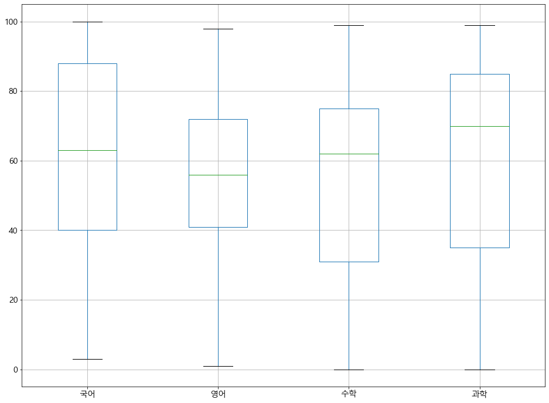

```python
성적표df.boxplot()
```

### 특정 컬럼만을 상자그림으로 표시

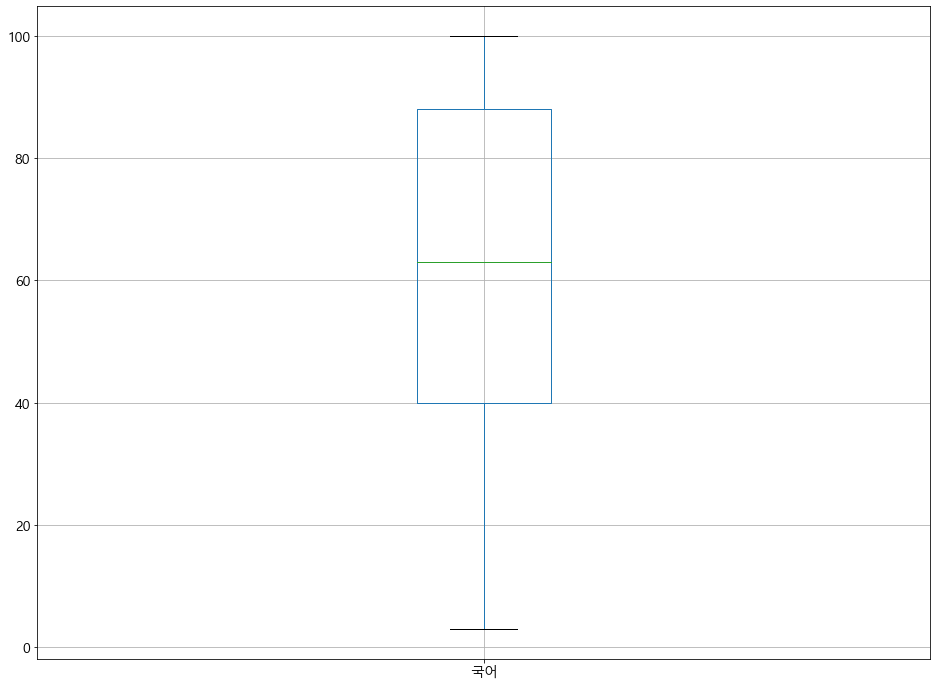

```python
# 표현할 컬럼이름들을 리스트로 지정 (두 개 이상 가능함)
성적표df.boxplot(["국어"])

# 이미지 저장, dpi는 해상도 비율 (기본값=100)
pyplot.savefig("국어점수분포.png", dpi=200)
```